# Convolution neural network beyond the human eyes

### 6.1 Test set Prediction

```python
y_pred = np.argmax(classifier3.predict(test_set), axis=-1)
y_pred
```

```
array([0, 0, 1, ..., 1, 1, 1], dtype=int64)
```

```python
y_true = test_set.classes
y_true
```

```
array([0, 0, 0, ..., 1, 1, 1])
```

```python
cm = confusion_matrix(y_true, y_pred)
cm
```

```
array([[1880,  120],
       [ 113, 1887]], dtype=int64)
```

```python
target_names = ['female', 'male']
cr = classification_report(y_true, y_pred, target_names=target_names)
print(cr)
```

```
              precision    recall  f1-score   support

      female       0.94      0.94      0.94      2000
        male       0.94      0.94      0.94      2000

    accuracy                           0.94      4000
   macro avg       0.94      0.94      0.94      4000
weighted avg       0.94      0.94      0.94      4000
```

```
confusion matrix, without normalization
[[1880  120]
 [ 113 1887]]
```

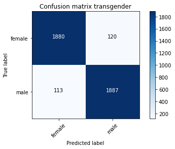

```python
plot_confusion_matrix(cm=cm, classes=target_names, title="Confusion matrix transgender")
```

### 6.2 Trangender Prediction

```python
y_pred_trans = np.argmax(classifier3.predict(Test_trans_set), axis=-1)
y_pred_trans
```

```
array([1, 0, 1, ..., 0, 0, 0], dtype=int64)
```

```python
y_true_trans = Test_trans_set.classes
y_true_trans
```

```
array([0, 0, 0, ..., 1, 1, 1])
```

```python
target_names = ['female', 'male']
cr_trans = classification_report(y_true_trans, y_pred_trans, target_names=target_names)
print(cr_trans)
```

```
              precision    recall  f1-score   support

      female       0.22      0.22      0.22       660
        male       0.21      0.21      0.21       660

    accuracy                           0.22      1320
   macro avg       0.22      0.22      0.22      1320
weighted avg       0.22      0.22      0.22      1320
```

[output not shown]

[figure not shown]

```python
plot_confusion_matrix(cm=cm_trans, classes=target_names, title="Confusion matrix transgender")
```

# 7. Optimizing The model with TensorBoard

Back to TOC

### In order to tune the model, differents combinations of dense layers, convolution layers, dropout values and optimizers were tested. Using tensorboard was possible to view which combination provides better results and the right epoch to stop training the model and avoid overfitting.

### combinations:

```
    dense_layers = [0, 1, 2]
    layers_sizes= [32, 64, 128]
    conv_layers = [1,2,3]
    dropout_values =[0.3, 0.5]
    optimizer_values= ["adam", 'rmsprop']
```

```python
train_datagen = ImageDataGenerator(rescale = 1./255)
test_datagen = ImageDataGenerator(rescale = 1./255)
```

```python
training_set = train_datagen.flow_from_directory('dataset/Training',
                                                 target_size = (64, 64),
                                                 batch_size = 32,
                                                 class_mode = 'categorical')

val_set = test_datagen.flow_from_directory('dataset/Validation',
                                            target_size = (64, 64),
                                            batch_size = 32,
                                            classes = ['female', 'male'])
                                            #class_mode = 'binary'
                                            # , shuffle=False

test_set = test_datagen.flow_from_directory('dataset/Test',
                                            target_size = (64, 64),
                                            batch_size = 32,
                                            classes = ['female', 'male'], shuffle=False)
                                            #class_mode = 'binary'

Test_trans_set = test_datagen.flow_from_directory('dataset/Test_trans',
                                            target_size = (64, 64),
                                            batch_size = 32,
                                            classes = ['female', 'male'], shuffle=False)
                                            #class_mode = 'binary'
```

```
Found 43009 images belonging to 2 classes.
Found 11649 images belonging to 2 classes.
Found 4000 images belonging to 2 classes.
Found 1320 images belonging to 2 classes.
```

```python
dense_layers = [0, 1, 2]
layers_sizes= [32, 64, 128]
conv_layers = [1,2,3]
dropout_values =[0.3, 0.5]
optimizer_values= ["adam", 'rmsprop']
```

```python
for dense_layer in dense_layers:
    for layers_size in layers_sizes:
        for conv_layer in conv_layers:
            for dropout_value in dropout_values:
                for optimizer_value in optimizer_values:
                    Name = "{}-conv-{}-nodes-{}-dense-{}-dropout-{}-optimizer-{}".format(conv_layer, layers_size, dense_layer, dropout_value, optimizer_value, int(time.time()))
                    print(Name)
                    # Initialising the CNN
                    classifier_tensorboard = Sequential()

                    # Step 1 - Convolution
                    classifier_tensorboard.add(Conv2D(layers_size, (3, 3), input_shape = (64, 64, 3), activation = 'relu'))

                    # Step 2 - Pooling
                    classifier_tensorboard.add(MaxPooling2D(pool_size = (2, 2)))

                    for l in range(conv_layer-1):
                        # Adding a second convolutional layer
                        classifier_tensorboard.add(Conv2D(layers_size, (3, 3), activation = 'relu'))
                        classifier_tensorboard.add(MaxPooling2D(pool_size = (2, 2)))

                    # Step 3 - Flattening
                    classifier_tensorboard.add(Flatten())
                    # Adding dropout
                    for l in dropout_values:
                        classifier_tensorboard.add(layers.Dropout(dropout_value))

                    for l in range(dense_layer):
                        classifier_tensorboard.add(Dense(units = layers_size, activation = 'relu'))


                    classifier_tensorboard.add(Dense(units = 2, activation = 'softmax'))

                    # Compiling the CNN
                    for l in range(len(optimizer_values)):
                        classifier_tensorboard.compile(optimizer = optimizer_value, loss = 'categorical_crossentropy', metrics = ['accuracy'])

                    classifier_tensorboard.fit(training_set,
                         steps_per_epoch = 1344, # if batch_size=1 -> steps_per_epoch=8000
                         epochs = 20,
                         validation_data = val_set,
                         #validation_steps = 50,
                         callbacks=[EarlyStopping(monitor = "accuracy", patience=3),
                                    TensorBoard(log_dir="logs/{}".format(Name))])#
```

```
1-conv-32-nodes-0-dense-0.3-dropout-adam-optimizer-1617020277
1-conv-32-nodes-0-dense-0.3-dropout-rmsprop-optimizer-1617021775
1-conv-32-nodes-0-dense-0.5-dropout-adam-optimizer-1617022791
1-conv-32-nodes-0-dense-0.5-dropout-rmsprop-optimizer-1617023951
2-conv-32-nodes-0-dense-0.3-dropout-adam-optimizer-1617024570
2-conv-32-nodes-0-dense-0.3-dropout-rmsprop-optimizer-1617026282
2-conv-32-nodes-0-dense-0.5-dropout-adam-optimizer-1617027697
2-conv-32-nodes-0-dense-0.5-dropout-rmsprop-optimizer-1617029335
3-conv-32-nodes-0-dense-0.3-dropout-adam-optimizer-1617030992
3-conv-32-nodes-0-dense-0.3-dropout-rmsprop-optimizer-1617032302
3-conv-32-nodes-0-dense-0.5-dropout-adam-optimizer-1617033510
3-conv-32-nodes-0-dense-0.5-dropout-rmsprop-optimizer-1617035205
1-conv-64-nodes-0-dense-0.3-dropout-adam-optimizer-1617036098
1-conv-64-nodes-0-dense-0.3-dropout-rmsprop-optimizer-1617038449
1-conv-64-nodes-0-dense-0.5-dropout-adam-optimizer-1617040734
1-conv-64-nodes-0-dense-0.5-dropout-rmsprop-optimizer-1617042508
2-conv-64-nodes-0-dense-0.3-dropout-adam-optimizer-1617043592
2-conv-64-nodes-0-dense-0.3-dropout-rmsprop-optimizer-1617046455
2-conv-64-nodes-0-dense-0.5-dropout-adam-optimizer-1617048153
2-conv-64-nodes-0-dense-0.5-dropout-rmsprop-optimizer-1617050955
3-conv-64-nodes-0-dense-0.3-dropout-adam-optimizer-1617052558
3-conv-64-nodes-0-dense-0.3-dropout-rmsprop-optimizer-1617055563
3-conv-64-nodes-0-dense-0.5-dropout-adam-optimizer-1617057826
3-conv-64-nodes-0-dense-0.5-dropout-rmsprop-optimizer-1617060497
1-conv-128-nodes-0-dense-0.3-dropout-adam-optimizer-1617061997
1-conv-128-nodes-0-dense-0.3-dropout-rmsprop-optimizer-1617066301
1-conv-128-nodes-0-dense-0.5-dropout-adam-optimizer-1617070644
1-conv-128-nodes-0-dense-0.5-dropout-rmsprop-optimizer-1617074964
2-conv-128-nodes-0-dense-0.3-dropout-adam-optimizer-1617076515
2-conv-128-nodes-0-dense-0.3-dropout-rmsprop-optimizer-1617082324
2-conv-128-nodes-0-dense-0.5-dropout-adam-optimizer-1617084988
2-conv-128-nodes-0-dense-0.5-dropout-rmsprop-optimizer-1617090587
3-conv-128-nodes-0-dense-0.3-dropout-adam-optimizer-1617093143
3-conv-128-nodes-0-dense-0.3-dropout-rmsprop-optimizer-1617098965
3-conv-128-nodes-0-dense-0.5-dropout-adam-optimizer-1617101629
3-conv-128-nodes-0-dense-0.5-dropout-rmsprop-optimizer-1617107632
1-conv-32-nodes-1-dense-0.3-dropout-adam-optimizer-1617110312
1-conv-32-nodes-1-dense-0.3-dropout-rmsprop-optimizer-1617111629
1-conv-32-nodes-1-dense-0.5-dropout-adam-optimizer-1617113379
1-conv-32-nodes-1-dense-0.5-dropout-rmsprop-optimizer-1617114771
```

[output cut: 53 more lines]

```
3-conv-64-nodes-2-dense-0.3-dropout-rmsprop-optimizer-1617300045
3-conv-64-nodes-2-dense-0.5-dropout-adam-optimizer-1617303559
3-conv-64-nodes-2-dense-0.5-dropout-rmsprop-optimizer-1617306946
1-conv-128-nodes-2-dense-0.3-dropout-adam-optimizer-1617309359
1-conv-128-nodes-2-dense-0.3-dropout-rmsprop-optimizer-1617315728
1-conv-128-nodes-2-dense-0.5-dropout-adam-optimizer-1617323953
1-conv-128-nodes-2-dense-0.5-dropout-rmsprop-optimizer-1617330793
2-conv-128-nodes-2-dense-0.3-dropout-adam-optimizer-1617339293
2-conv-128-nodes-2-dense-0.3-dropout-rmsprop-optimizer-1617345977
2-conv-128-nodes-2-dense-0.5-dropout-adam-optimizer-1617350212
2-conv-128-nodes-2-dense-0.5-dropout-rmsprop-optimizer-1617356969
3-conv-128-nodes-2-dense-0.3-dropout-adam-optimizer-1617362711
3-conv-128-nodes-2-dense-0.3-dropout-rmsprop-optimizer-1617370194
3-conv-128-nodes-2-dense-0.5-dropout-adam-optimizer-1617373379
3-conv-128-nodes-2-dense-0.5-dropout-rmsprop-optimizer-1617381064
```

```python
# Initialising the CNN
bestmodel = Sequential()

# Step 1 - Convolution
bestmodel.add(Conv2D(32, (3, 3), input_shape = (64, 64, 3), activation = 'relu'))

# Step 2 - Pooling
bestmodel.add(MaxPooling2D(pool_size = (2, 2)))

# Adding a second convolutional layer
bestmodel.add(Conv2D(32, (3, 3), activation = 'relu'))
bestmodel.add(MaxPooling2D(pool_size = (2, 2)))

# Adding a second convolutional layer
bestmodel.add(Conv2D(32, (3, 3), activation = 'relu'))
bestmodel.add(MaxPooling2D(pool_size = (2, 2)))

# Step 3 - Flattening
bestmodel.add(Flatten())

# Adding dropout
bestmodel.add(layers.Dropout(0.3))

# Step 4 - Full connection
bestmodel.add(Dense(units = 64, activation = 'relu'))
bestmodel.add(Dense(units = 2, activation = 'softmax'))

bestmodel.summary()
```

```
Model: "sequential_4"
_________________________________________________________________
Layer (type)                 Output Shape              Param #
=================================================================
conv2d_10 (Conv2D)           (None, 62, 62, 32)        896
_________________________________________________________________
max_pooling2d_9 (MaxPooling2 (None, 31, 31, 32)        0
_________________________________________________________________
conv2d_11 (Conv2D)           (None, 29, 29, 32)        9248
_________________________________________________________________
max_pooling2d_10 (MaxPooling (None, 14, 14, 32)        0
_________________________________________________________________
conv2d_12 (Conv2D)           (None, 12, 12, 32)        9248
_________________________________________________________________
max_pooling2d_11 (MaxPooling (None, 6, 6, 32)          0
_________________________________________________________________
flatten_3 (Flatten)          (None, 1152)              0
_________________________________________________________________
dropout_1 (Dropout)          (None, 1152)              0
_________________________________________________________________
dense_4 (Dense)              (None, 64)                73792
_________________________________________________________________
dense_5 (Dense)              (None, 2)                 130
=================================================================
Total params: 93,314
Trainable params: 93,314
Non-trainable params: 0
_________________________________________________________________
```

```python
# Compiling the CNN
bestmodel.compile(optimizer = 'adam', loss = 'categorical_crossentropy', metrics = ['accuracy'])
```

```python
history=bestmodel.fit(training_set,
                         steps_per_epoch = 1344, # if batch_size=1 -> steps_per_epoch=8000
                         epochs = 12,
                         validation_data = val_set,
                         validation_steps = 50)
```

### 7.1 Test set Prediction

```python
y_pred = np.argmax(bestmodel.predict(test_set), axis=-1)
y_pred
```

```
array([0, 0, 0, ..., 1, 1, 1], dtype=int64)
```

```python
y_true = test_set.classes
y_true
```

```
array([0, 0, 0, ..., 1, 1, 1])
```

```python
cm = confusion_matrix(y_true, y_pred)
cm
```

```
array([[1913,   87],
       [  62, 1938]], dtype=int64)
```

```python
target_names = ['female', 'male']
cr = classification_report(y_true, y_pred, target_names=target_names)
print(cr)
```

```
              precision    recall  f1-score   support

      female       0.97      0.96      0.96      2000
        male       0.96      0.97      0.96      2000

    accuracy                           0.96      4000
   macro avg       0.96      0.96      0.96      4000
weighted avg       0.96      0.96      0.96      4000
```

```
confusion matrix, without normalization
[[1913   87]
 [  62 1938]]
```

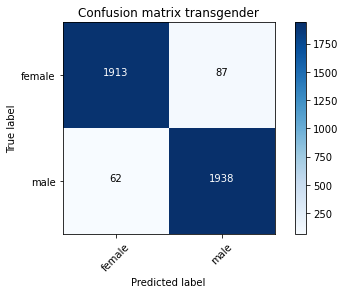

```python
plot_confusion_matrix(cm=cm, classes=target_names, title="Confusion matrix transgender")
```

### 7.2 Trangender Prediction

```python
y_pred_trans = np.argmax(bestmodel.predict(Test_trans_set), axis=-1)
y_pred_trans
```

```
array([1, 1, 1, ..., 0, 0, 0], dtype=int64)
```

```python
y_true_trans = Test_trans_set.classes
y_true_trans
```

```
array([0, 0, 0, ..., 1, 1, 1])
```

```python
target_names = ['female', 'male']
cr_trans = classification_report(y_true_trans, y_pred_trans, target_names=target_names)
print(cr_trans)
```

```
              precision    recall  f1-score   support

      female       0.13      0.09      0.11       660
        male       0.28      0.36      0.32       660

    accuracy                           0.23      1320
   macro avg       0.21      0.23      0.21      1320
weighted avg       0.21      0.23      0.21      1320
```

[output not shown]

[figure not shown]

```python
plot_confusion_matrix(cm=cm_trans, classes=target_names, title="Confusion matrix transgender")
```

# 8. Transfer learning

Back to TOC

Building a neural network for image classification is not always easy when you don’t have a lot of data. In recent years, there have been a few major advances in this space that have made building a valuable model more possible without having millions of images to train on. Most notably, transfer learning tops this list.

## 8.1 Competition-winning deep neural networks

competition-winning deep neural networks with pretrained weights are used for image-based gender recognition and age estimation. Transfer learning is explored using both VGG19 and VGGFace pretrained models

# 9. Train a Fine-Tuned Neural Network with TensorFlow's Keras API

Back to TOC

# 1. VGG16

### a) Bulid the Model

VGG16 is a convolution neural net (CNN ) architecture which was used to win ILSVR(Imagenet) competition in 2014. It is considered to be one of the excellent vision model architecture till date.

```python
from tensorflow.keras.applications.vgg16 import VGG16
from tensorflow.keras.preprocessing import image
from tensorflow.keras.applications.vgg16 import preprocess_input
import tensorflow as tf
```

```python
base_model = tf.keras.applications.vgg16.VGG16()
```

```python
base_model.summary()
```

```
Model: "vgg16"
_________________________________________________________________
Layer (type)                 Output Shape              Param #
=================================================================
input_7 (InputLayer)         [(None, 224, 224, 3)]     0
_________________________________________________________________
block1_conv1 (Conv2D)        (None, 224, 224, 64)      1792
_________________________________________________________________
block1_conv2 (Conv2D)        (None, 224, 224, 64)      36928
_________________________________________________________________
block1_pool (MaxPooling2D)   (None, 112, 112, 64)      0
_________________________________________________________________
block2_conv1 (Conv2D)        (None, 112, 112, 128)     73856
_________________________________________________________________
block2_conv2 (Conv2D)        (None, 112, 112, 128)     147584
_________________________________________________________________
block2_pool (MaxPooling2D)   (None, 56, 56, 128)       0
_________________________________________________________________
block3_conv1 (Conv2D)        (None, 56, 56, 256)       295168
_________________________________________________________________
block3_conv2 (Conv2D)        (None, 56, 56, 256)       590080
_________________________________________________________________
block3_conv3 (Conv2D)        (None, 56, 56, 256)       590080
_________________________________________________________________
block3_pool (MaxPooling2D)   (None, 28, 28, 256)       0
_________________________________________________________________
block4_conv1 (Conv2D)        (None, 28, 28, 512)       1180160
_________________________________________________________________
block4_conv2 (Conv2D)        (None, 28, 28, 512)       2359808
_________________________________________________________________
block4_conv3 (Conv2D)        (None, 28, 28, 512)       2359808
_________________________________________________________________
block4_pool (MaxPooling2D)   (None, 14, 14, 512)       0
_________________________________________________________________
block5_conv1 (Conv2D)        (None, 14, 14, 512)       2359808
_________________________________________________________________
block5_conv2 (Conv2D)        (None, 14, 14, 512)       2359808
_________________________________________________________________
block5_conv3 (Conv2D)        (None, 14, 14, 512)       2359808
_________________________________________________________________
block5_pool (MaxPooling2D)   (None, 7, 7, 512)         0
_________________________________________________________________
flatten (Flatten)            (None, 25088)             0
_________________________________________________________________
fc1 (Dense)                  (None, 4096)              102764544
_________________________________________________________________
fc2 (Dense)                  (None, 4096)              16781312
_________________________________________________________________
predictions (Dense)          (None, 1000)              4097000
=================================================================
Total params: 138,357,544
Trainable params: 138,357,544
Non-trainable params: 0
_________________________________________________________________
```

```python
type(base_model)
```

```
tensorflow.python.keras.engine.functional.Functional
```

```python
VGG16_model = Sequential()
for layer in base_model.layers[:-1]:
    VGG16_model.add(layer)
```

```python
for layer in VGG16_model.layers:
    layer.trainable = False
```

```python
VGG16_model.add(Dense(units=2, activation='softmax'))
```

```python
VGG16_model.summary()
```

```
Model: "sequential_2"
_________________________________________________________________
Layer (type)                 Output Shape              Param #
=================================================================
block1_conv1 (Conv2D)        (None, 224, 224, 64)      1792
_________________________________________________________________
block1_conv2 (Conv2D)        (None, 224, 224, 64)      36928
_________________________________________________________________
block1_pool (MaxPooling2D)   (None, 112, 112, 64)      0
_________________________________________________________________
block2_conv1 (Conv2D)        (None, 112, 112, 128)     73856
_________________________________________________________________
block2_conv2 (Conv2D)        (None, 112, 112, 128)     147584
_________________________________________________________________
block2_pool (MaxPooling2D)   (None, 56, 56, 128)       0
_________________________________________________________________
block3_conv1 (Conv2D)        (None, 56, 56, 256)       295168
_________________________________________________________________
block3_conv2 (Conv2D)        (None, 56, 56, 256)       590080
_________________________________________________________________
block3_conv3 (Conv2D)        (None, 56, 56, 256)       590080
_________________________________________________________________
block3_pool (MaxPooling2D)   (None, 28, 28, 256)       0
_________________________________________________________________
block4_conv1 (Conv2D)        (None, 28, 28, 512)       1180160
_________________________________________________________________
block4_conv2 (Conv2D)        (None, 28, 28, 512)       2359808
_________________________________________________________________
block4_conv3 (Conv2D)        (None, 28, 28, 512)       2359808
_________________________________________________________________
block4_pool (MaxPooling2D)   (None, 14, 14, 512)       0
_________________________________________________________________
block5_conv1 (Conv2D)        (None, 14, 14, 512)       2359808
_________________________________________________________________
block5_conv2 (Conv2D)        (None, 14, 14, 512)       2359808
_________________________________________________________________
block5_conv3 (Conv2D)        (None, 14, 14, 512)       2359808
_________________________________________________________________
block5_pool (MaxPooling2D)   (None, 7, 7, 512)         0
_________________________________________________________________
flatten (Flatten)            (None, 25088)             0
_________________________________________________________________
fc1 (Dense)                  (None, 4096)              102764544
_________________________________________________________________
fc2 (Dense)                  (None, 4096)              16781312
_________________________________________________________________
dense_9 (Dense)              (None, 2)                 8194
=================================================================
Total params: 134,268,738
Trainable params: 8,194
Non-trainable params: 134,260,544
_________________________________________________________________
```

```python
VGG16_model.compile(optimizer = 'adam', loss = 'categorical_crossentropy', metrics = ['accuracy'])
```

### b) Preprocessing

```python
train_datagen = ImageDataGenerator(preprocessing_function=tf.keras.applications.vgg16.preprocess_input)

test_datagen = ImageDataGenerator(preprocessing_function=tf.keras.applications.vgg16.preprocess_input)
```

```python
training_set = train_datagen.flow_from_directory('dataset/Training',
                                                 target_size = (224, 224),
                                                 batch_size = 10,
                                                 class_mode = 'categorical')

val_set = test_datagen.flow_from_directory('dataset/Validation',
                                            target_size = (224, 224),
                                                 batch_size = 10,
                                                class_mode = 'categorical')
                                            #class_mode = 'binary'

test_set = test_datagen.flow_from_directory('dataset/Test',
                                            target_size = (224, 224),
                                            batch_size = 10,
                                            class_mode = 'categorical', shuffle=False)
                                            #class_mode = 'binary'

Test_trans_set = test_datagen.flow_from_directory('dataset/Test_trans',
                                            target_size = (224, 224),
                                            batch_size = 10,
                                            class_mode = 'categorical', shuffle=False)
                                            #class_mode = 'binary'
```

```
Found 43009 images belonging to 2 classes.
Found 11649 images belonging to 2 classes.
Found 4000 images belonging to 2 classes.
Found 1320 images belonging to 2 classes.
```

### c) Train the model

```python
history=VGG16_model.fit(training_set,
                         steps_per_epoch = 1344, # if batch_size=1 -> steps_per_epoch=8000
                         epochs = 5,
                         validation_data = val_set,
                         validation_steps = 50)
```

```python
# # save the model
# VGG16_model.save('VGG16_model.h5')
```

```python
# # Loading the model
# VGG16_model = load_model('VGG16_model.h5')
# VGG16_model.summary()
```

[output not shown]

### d) Displaying curves of loss and accuracy during training

```python
#history_dict = history.history
acc = history.history['accuracy']
val_acc = history.history['val_accuracy']
loss = history.history['loss']
val_loss = history.history['val_loss']

epochs = range(1, len(acc) + 1)
```

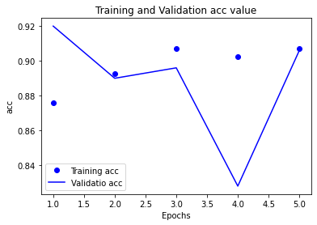

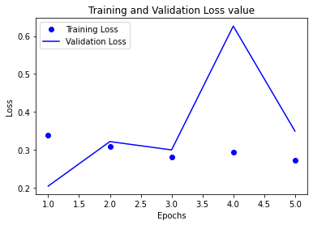

```python
plt.plot(epochs, acc, 'bo', label='Training acc')
plt.plot(epochs, val_acc, 'b', label='Validatio acc')
plt.title('Training and Validation acc value')
plt.xlabel('Epochs')
plt.ylabel('acc')
plt.legend()

plt.figure()

plt.plot(epochs, loss, 'bo', label='Training Loss')
plt.plot(epochs, val_loss, 'b', label='Validation Loss')
plt.title('Training and Validation Loss value')
plt.xlabel('Epochs')
plt.ylabel('Loss')
plt.legend()

plt.show()
```

### e) Male & Famele Prediction

```python
y_pred = np.argmax(VGG16_model.predict(test_set), axis=-1)
y_pred
```

```
array([0, 0, 0, ..., 1, 1, 1], dtype=int64)
```

```python
y_true = test_set.classes
y_true
```

```
array([0, 0, 0, ..., 1, 1, 1])
```

```python
cm = confusion_matrix(y_true, y_pred)
cm
```

```
array([[1679,  321],
       [  67, 1933]], dtype=int64)
```

```python
target_names = ['female', 'male']
cr = classification_report(y_true, y_pred, target_names=target_names)
print(cr)
```

```
              precision    recall  f1-score   support

      female       0.96      0.84      0.90      2000
        male       0.86      0.97      0.91      2000

    accuracy                           0.90      4000
   macro avg       0.91      0.90      0.90      4000
weighted avg       0.91      0.90      0.90      4000
```

```
confusion matrix, without normalization
[[1679  321]
 [  67 1933]]
```

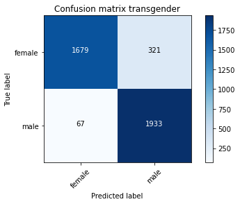

```python
plot_confusion_matrix(cm=cm, classes=target_names, title="Confusion matrix transgender")
```

### f) Trangender Prediction

```python
y_pred_trans = np.argmax(VGG16_model.predict(Test_trans_set), axis=-1)
y_pred_trans
```

```
array([0, 0, 1, ..., 0, 0, 0], dtype=int64)
```

```python
y_true_trans = Test_trans_set.classes
y_true_trans
```

```
array([0, 0, 0, ..., 1, 1, 1])
```

```python
cm_trans = confusion_matrix(y_true_trans, y_pred_trans)
cm_trans
```

```
array([[182, 478],
       [568,  92]], dtype=int64)
```

```python
target_names = ['female', 'male']
cr_trans = classification_report(y_true_trans, y_pred_trans, target_names=target_names)
print(cr_trans)
```

```
              precision    recall  f1-score   support

      female       0.24      0.28      0.26       660
        male       0.16      0.14      0.15       660

    accuracy                           0.21      1320
   macro avg       0.20      0.21      0.20      1320
weighted avg       0.20      0.21      0.20      1320
```

```
confusion matrix, without normalization
[[182 478]
 [568  92]]
```

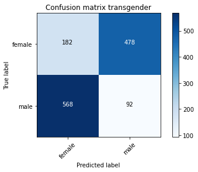

```python
plot_confusion_matrix(cm=cm_trans, classes=target_names, title="Confusion matrix transgender")
```

# 2. VGG19

### a) Build the Model

```python
from tensorflow.keras.applications.vgg19 import VGG19
from tensorflow.keras.preprocessing import image
from tensorflow.keras.applications.vgg19 import preprocess_input
```

```python
base_model = tf.keras.applications.vgg19.VGG19()
```

```python
base_model.summary()
```

```
Model: "vgg19"
_________________________________________________________________
Layer (type)                 Output Shape              Param #
=================================================================
input_2 (InputLayer)         [(None, 224, 224, 3)]     0
_________________________________________________________________
block1_conv1 (Conv2D)        (None, 224, 224, 64)      1792
_________________________________________________________________
block1_conv2 (Conv2D)        (None, 224, 224, 64)      36928
_________________________________________________________________
block1_pool (MaxPooling2D)   (None, 112, 112, 64)      0
_________________________________________________________________
block2_conv1 (Conv2D)        (None, 112, 112, 128)     73856
_________________________________________________________________
block2_conv2 (Conv2D)        (None, 112, 112, 128)     147584
_________________________________________________________________
block2_pool (MaxPooling2D)   (None, 56, 56, 128)       0
_________________________________________________________________
block3_conv1 (Conv2D)        (None, 56, 56, 256)       295168
_________________________________________________________________
block3_conv2 (Conv2D)        (None, 56, 56, 256)       590080
_________________________________________________________________
block3_conv3 (Conv2D)        (None, 56, 56, 256)       590080
_________________________________________________________________
block3_conv4 (Conv2D)        (None, 56, 56, 256)       590080
_________________________________________________________________
block3_pool (MaxPooling2D)   (None, 28, 28, 256)       0
_________________________________________________________________
block4_conv1 (Conv2D)        (None, 28, 28, 512)       1180160
_________________________________________________________________
block4_conv2 (Conv2D)        (None, 28, 28, 512)       2359808
_________________________________________________________________
block4_conv3 (Conv2D)        (None, 28, 28, 512)       2359808
_________________________________________________________________
block4_conv4 (Conv2D)        (None, 28, 28, 512)       2359808
_________________________________________________________________
block4_pool (MaxPooling2D)   (None, 14, 14, 512)       0
_________________________________________________________________
block5_conv1 (Conv2D)        (None, 14, 14, 512)       2359808
_________________________________________________________________
block5_conv2 (Conv2D)        (None, 14, 14, 512)       2359808
_________________________________________________________________
block5_conv3 (Conv2D)        (None, 14, 14, 512)       2359808
_________________________________________________________________
block5_conv4 (Conv2D)        (None, 14, 14, 512)       2359808
_________________________________________________________________
block5_pool (MaxPooling2D)   (None, 7, 7, 512)         0
_________________________________________________________________
flatten (Flatten)            (None, 25088)             0
_________________________________________________________________
fc1 (Dense)                  (None, 4096)              102764544
_________________________________________________________________
fc2 (Dense)                  (None, 4096)              16781312
_________________________________________________________________
predictions (Dense)          (None, 1000)              4097000
=================================================================
Total params: 143,667,240
Trainable params: 143,667,240
Non-trainable params: 0
_________________________________________________________________
```

```python
VGG19_model = Sequential()
for layer in base_model.layers[:-1]:
    VGG19_model.add(layer)
```

```python
for layer in VGG19_model.layers:
    layer.trainable = False
```

```python
VGG19_model.add(Dense(units=2, activation='softmax'))
```

```python
VGG19_model.compile(optimizer = 'adam', loss = 'categorical_crossentropy', metrics = ['accuracy'])
```

### b) Preprocessing

```python
train_datagen = ImageDataGenerator(preprocessing_function=tf.keras.applications.vgg19.preprocess_input)

test_datagen = ImageDataGenerator(preprocessing_function=tf.keras.applications.vgg19.preprocess_input)
```

```python
training_set = train_datagen.flow_from_directory('dataset/Training',
                                                 target_size = (224, 224),
                                                 batch_size = 10,
                                                 class_mode = 'categorical')

val_set = test_datagen.flow_from_directory('dataset/Validation',
                                            target_size = (224, 224),
                                                 batch_size = 10,
                                                class_mode = 'categorical')
                                            #class_mode = 'binary'

test_set = test_datagen.flow_from_directory('dataset/Test',
                                            target_size = (224, 224),
                                            batch_size = 10,
                                            class_mode = 'categorical', shuffle=False)
                                            #class_mode = 'binary'

Test_trans_set = test_datagen.flow_from_directory('dataset/Test_trans',
                                            target_size = (224, 224),
                                            batch_size = 10,
                                            class_mode = 'categorical', shuffle=False)
                                            #class_mode = 'binary'
```

```
Found 43009 images belonging to 2 classes.
Found 11649 images belonging to 2 classes.
Found 4000 images belonging to 2 classes.
Found 1320 images belonging to 2 classes.
```

### c) Train the Model

```python
history=VGG19_model.fit(training_set,
                         steps_per_epoch = 1344, # if batch_size=1 -> steps_per_epoch=8000
                         epochs = 5,
                         validation_data = val_set,
                         validation_steps = 50)
```

```python
# # save the model
# VGG19_model.save('VGG19_model.h5')
```

```python
# # Loading the model
# VGG19_model = load_model('VGG19_model.h5')
# VGG19_model.summary()
```

[output not shown]

### d) Displaying curves of loss and accuracy during training

```python
#history_dict = history.history
acc = history.history['accuracy']
val_acc = history.history['val_accuracy']
loss = history.history['loss']
val_loss = history.history['val_loss']

epochs = range(1, len(acc) + 1)
```

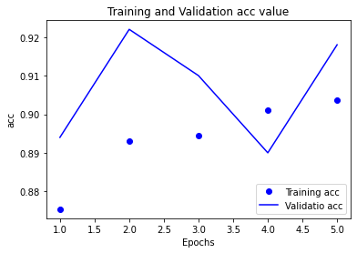

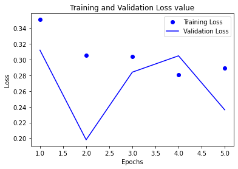

```python
plt.plot(epochs, acc, 'bo', label='Training acc')
plt.plot(epochs, val_acc, 'b', label='Validatio acc')
plt.title('Training and Validation acc value')
plt.xlabel('Epochs')
plt.ylabel('acc')
plt.legend()

plt.figure()

plt.plot(epochs, loss, 'bo', label='Training Loss')
plt.plot(epochs, val_loss, 'b', label='Validation Loss')
plt.title('Training and Validation Loss value')
plt.xlabel('Epochs')
plt.ylabel('Loss')
plt.legend()

plt.show()
```

### e) Male & Famele Prediction

```python
y_pred = np.argmax(VGG19_model.predict(test_set), axis=-1)
y_pred
```

```
array([0, 0, 0, ..., 0, 1, 1], dtype=int64)
```

```python
y_true = test_set.classes
y_true
```

```
array([0, 0, 0, ..., 1, 1, 1])
```

```python
cm = confusion_matrix(y_true, y_pred)
cm
```

```
array([[1901,   99],
       [ 239, 1761]], dtype=int64)
```

```python
target_names = ['female', 'male']
cr = classification_report(y_true, y_pred, target_names=target_names)
print(cr)
```

```
              precision    recall  f1-score   support

      female       0.89      0.95      0.92      2000
        male       0.95      0.88      0.91      2000

    accuracy                           0.92      4000
   macro avg       0.92      0.92      0.92      4000
weighted avg       0.92      0.92      0.92      4000
```

```
confusion matrix, without normalization
[[1901   99]
 [ 239 1761]]
```

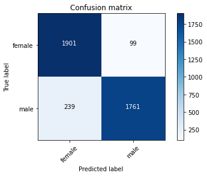

```python
plot_confusion_matrix(cm=cm, classes=target_names, title="Confusion matrix")
```

### f) Transgender Prediction

```python
y_pred_trans = np.argmax(VGG19_model.predict(Test_trans_set), axis=-1)
y_pred_trans
```

```
array([0, 0, 1, ..., 0, 0, 0], dtype=int64)
```

```python
y_true_trans = Test_trans_set.classes
y_true_trans
```

```
array([0, 0, 0, ..., 1, 1, 1])
```

```python
cm_trans = confusion_matrix(y_true_trans, y_pred_trans)
cm_trans
```

```
array([[210, 450],
       [590,  70]], dtype=int64)
```

```python
target_names = ['female', 'male']
cr_trans = classification_report(y_true_trans, y_pred_trans, target_names=target_names)
print(cr_trans)
```

```
              precision    recall  f1-score   support

      female       0.26      0.32      0.29       660
        male       0.13      0.11      0.12       660

    accuracy                           0.21      1320
   macro avg       0.20      0.21      0.20      1320
weighted avg       0.20      0.21      0.20      1320
```

```
confusion matrix, without normalization
[[210 450]
 [590  70]]
```

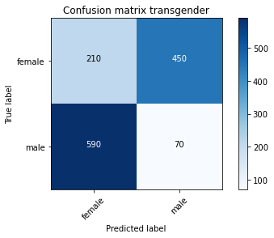

```python
plot_confusion_matrix(cm=cm_trans, classes=target_names, title="Confusion matrix transgender")
```

# 3. VGGFace

Shortly after the release of the VGG architectures, the Visual Geometry Group published another paper called “Deep Face Recognition” [24]. In this paper, VGG16 is trained from scratch for facial recognition using a dataset of 2.6 million face images. Prior studies have shown that transfer learning using neural networks with facial recognition pretraining can produce highly effective results for gender recognition and age estimation [16]. Since facial recognition neural networks have already been trained to distinguish human features, the features that they extract may be more useful for determining age and gender from a photo than the features extracted by a more general neural network.

[16] G. Antipov, M. Baccouche, S.-A. Berrani, and J.-L. Dugelay, “Effective Training of Convolutional Neural Networks for Face-based Gender and Age Prediction,” Pattern Recognition, vol. 72, p. 15–26, 2017. 1, 2, 3, 5

[24] O. M. Parkhi, A. Vedaldi, and A. Zisserman,“”Deep Face Recognition”,” in British Machine Vision Conference, 2015. 2, 6

The keras-vggface library provides three pre-trained VGGModels, a VGGFace1 model via model=’vgg16′ (the default), and two VGGFace2 models ‘resnet50‘ and ‘senet50‘.

In this project will be used ‘senet50‘ VGGFace2 model, the VGG16 and ResNet50 have been tested on the original version

```python
# pip install keras-vggface
```

```python
# pip install keras_applications
```

```python
from keras_vggface.vggface import VGGFace
from keras_vggface.utils import preprocess_input
from keras_vggface.utils import decode_predictions
```

### a) Build the Model

```python
# create the base pre-trained model
base_model = VGGFace(model='senet50', include_top=False)
```

```python
base_model.summary()
```

```
Model: "vggface_senet50"
__________________________________________________________________________________________________
Layer (type)                    Output Shape         Param #     Connected to
==================================================================================================
input_4 (InputLayer)            [(None, None, None,  0
__________________________________________________________________________________________________
conv1/7x7_s2 (Conv2D)           (None, None, None, 6 9408        input_4[0][0]
__________________________________________________________________________________________________
conv1/7x7_s2/bn (BatchNormaliza (None, None, None, 6 256         conv1/7x7_s2[0][0]
__________________________________________________________________________________________________
activation_81 (Activation)      (None, None, None, 6 0           conv1/7x7_s2/bn[0][0]
__________________________________________________________________________________________________
max_pooling2d_1 (MaxPooling2D)  (None, None, None, 6 0           activation_81[0][0]
__________________________________________________________________________________________________
conv2_1_1x1_reduce (Conv2D)     (None, None, None, 6 4096        max_pooling2d_1[0][0]
__________________________________________________________________________________________________
conv2_1_1x1_reduce/bn (BatchNor (None, None, None, 6 256         conv2_1_1x1_reduce[0][0]
__________________________________________________________________________________________________
activation_82 (Activation)      (None, None, None, 6 0           conv2_1_1x1_reduce/bn[0][0]
__________________________________________________________________________________________________
conv2_1_3x3 (Conv2D)            (None, None, None, 6 36864       activation_82[0][0]
__________________________________________________________________________________________________
conv2_1_3x3/bn (BatchNormalizat (None, None, None, 6 256         conv2_1_3x3[0][0]
__________________________________________________________________________________________________
activation_83 (Activation)      (None, None, None, 6 0           conv2_1_3x3/bn[0][0]
__________________________________________________________________________________________________
conv2_1_1x1_increase (Conv2D)   (None, None, None, 2 16384       activation_83[0][0]
__________________________________________________________________________________________________
conv2_1_1x1_increase/bn (BatchN (None, None, None, 2 1024        conv2_1_1x1_increase[0][0]
__________________________________________________________________________________________________
global_average_pooling2d_16 (Gl (None, 256)          0           conv2_1_1x1_increase/bn[0][0]
__________________________________________________________________________________________________
reshape_16 (Reshape)            (None, 1, 1, 256)    0           global_average_pooling2d_16[0][0]
__________________________________________________________________________________________________
conv2_1_1x1_down (Conv2D)       (None, 1, 1, 16)     4112        reshape_16[0][0]
__________________________________________________________________________________________________
activation_84 (Activation)      (None, 1, 1, 16)     0           conv2_1_1x1_down[0][0]
__________________________________________________________________________________________________
conv2_1_1x1_up (Conv2D)         (None, 1, 1, 256)    4352        activation_84[0][0]
__________________________________________________________________________________________________
```

[output cut: 557 more lines]

```
__________________________________________________________________________________________________
multiply_31 (Multiply)          (None, None, None, 2 0           conv5_3_1x1_increase/bn[0][0]
                                                                 activation_160[0][0]
__________________________________________________________________________________________________
add_31 (Add)                    (None, None, None, 2 0           multiply_31[0][0]
                                                                 activation_156[0][0]
__________________________________________________________________________________________________
activation_161 (Activation)     (None, None, None, 2 0           add_31[0][0]
__________________________________________________________________________________________________
avg_pool (AveragePooling2D)     (None, None, None, 2 0           activation_161[0][0]
==================================================================================================
Total params: 26,092,144
Trainable params: 26,039,024
Non-trainable params: 53,120
__________________________________________________________________________________________________
```

```python
# add a global spatial average pooling layer
x = base_model.output
x = GlobalAveragePooling2D()(x)
# let's add a fully-connected layer
x = Dense(1024, activation='relu')(x)
# and a prediction layer layer with 2 classes
predictions = Dense(2, activation='softmax')(x)

# this is the model we will train
VGGFace_model = Model(inputs=base_model.input, outputs=predictions)
```

```python
# first: train only the top layers (which were randomly initialized)
# i.e. freeze all convolutional InceptionV3 layers
for layer in base_model.layers:
    layer.trainable = False
```

```python
VGGFace_model.summary()
```

```
Model: "model"
__________________________________________________________________________________________________
Layer (type)                    Output Shape         Param #     Connected to
==================================================================================================
input_4 (InputLayer)            [(None, None, None,  0
__________________________________________________________________________________________________
conv1/7x7_s2 (Conv2D)           (None, None, None, 6 9408        input_4[0][0]
__________________________________________________________________________________________________
conv1/7x7_s2/bn (BatchNormaliza (None, None, None, 6 256         conv1/7x7_s2[0][0]
__________________________________________________________________________________________________
activation_81 (Activation)      (None, None, None, 6 0           conv1/7x7_s2/bn[0][0]
__________________________________________________________________________________________________
max_pooling2d_1 (MaxPooling2D)  (None, None, None, 6 0           activation_81[0][0]
__________________________________________________________________________________________________
conv2_1_1x1_reduce (Conv2D)     (None, None, None, 6 4096        max_pooling2d_1[0][0]
__________________________________________________________________________________________________
conv2_1_1x1_reduce/bn (BatchNor (None, None, None, 6 256         conv2_1_1x1_reduce[0][0]
__________________________________________________________________________________________________
activation_82 (Activation)      (None, None, None, 6 0           conv2_1_1x1_reduce/bn[0][0]
__________________________________________________________________________________________________
conv2_1_3x3 (Conv2D)            (None, None, None, 6 36864       activation_82[0][0]
__________________________________________________________________________________________________
conv2_1_3x3/bn (BatchNormalizat (None, None, None, 6 256         conv2_1_3x3[0][0]
__________________________________________________________________________________________________
activation_83 (Activation)      (None, None, None, 6 0           conv2_1_3x3/bn[0][0]
__________________________________________________________________________________________________
conv2_1_1x1_increase (Conv2D)   (None, None, None, 2 16384       activation_83[0][0]
__________________________________________________________________________________________________
conv2_1_1x1_increase/bn (BatchN (None, None, None, 2 1024        conv2_1_1x1_increase[0][0]
__________________________________________________________________________________________________
global_average_pooling2d_16 (Gl (None, 256)          0           conv2_1_1x1_increase/bn[0][0]
__________________________________________________________________________________________________
reshape_16 (Reshape)            (None, 1, 1, 256)    0           global_average_pooling2d_16[0][0]
__________________________________________________________________________________________________
conv2_1_1x1_down (Conv2D)       (None, 1, 1, 16)     4112        reshape_16[0][0]
__________________________________________________________________________________________________
activation_84 (Activation)      (None, 1, 1, 16)     0           conv2_1_1x1_down[0][0]
__________________________________________________________________________________________________
conv2_1_1x1_up (Conv2D)         (None, 1, 1, 256)    4352        activation_84[0][0]
__________________________________________________________________________________________________
```

[output cut: 563 more lines]

```
__________________________________________________________________________________________________
activation_161 (Activation)     (None, None, None, 2 0           add_31[0][0]
__________________________________________________________________________________________________
avg_pool (AveragePooling2D)     (None, None, None, 2 0           activation_161[0][0]
__________________________________________________________________________________________________
global_average_pooling2d_32 (Gl (None, 2048)         0           avg_pool[0][0]
__________________________________________________________________________________________________
dense_3 (Dense)                 (None, 1024)         2098176     global_average_pooling2d_32[0][0]
__________________________________________________________________________________________________
dense_4 (Dense)                 (None, 2)            2050        dense_3[0][0]
==================================================================================================
Total params: 28,192,370
Trainable params: 2,100,226
Non-trainable params: 26,092,144
__________________________________________________________________________________________________
```

```python
# let's visualize layer names and layer indices to see how many layers
# we should freeze:
for i, layer in enumerate(base_model.layers):
    print(i, layer.name)
```

```
0 input_4
1 conv1/7x7_s2
2 conv1/7x7_s2/bn
3 activation_81
4 max_pooling2d_1
5 conv2_1_1x1_reduce
6 conv2_1_1x1_reduce/bn
7 activation_82
8 conv2_1_3x3
9 conv2_1_3x3/bn
10 activation_83
11 conv2_1_1x1_increase
12 conv2_1_1x1_increase/bn
13 global_average_pooling2d_16
14 reshape_16
```

[output cut: 271 more lines]

```python
VGGFace_model.compile(optimizer = 'adam', loss = 'categorical_crossentropy', metrics = ['accuracy'])
```

### b) Preprocessing

```python
train_datagen = ImageDataGenerator(preprocessing_function=preprocess_input)

test_datagen = ImageDataGenerator(preprocessing_function=preprocess_input)
```

```python
training_set = train_datagen.flow_from_directory('dataset/Training',
                                                 target_size = (224, 224),
                                                 batch_size = 10,
                                                 class_mode = 'categorical')

val_set = test_datagen.flow_from_directory('dataset/Validation',
                                            target_size = (224, 224),
                                                 batch_size = 10,
                                                class_mode = 'categorical')
                                            #class_mode = 'binary'

test_set = test_datagen.flow_from_directory('dataset/Test',
                                            target_size = (224, 224),
                                            batch_size = 10,
                                            class_mode = 'categorical', shuffle=False)
                                            #class_mode = 'binary'

Test_trans_set = test_datagen.flow_from_directory('dataset/Test_trans',
                                            target_size = (224, 224),
                                            batch_size = 10,
                                            class_mode = 'categorical', shuffle=False)
                                            #class_mode = 'binary'
```

```
Found 43009 images belonging to 2 classes.
Found 11649 images belonging to 2 classes.
Found 4000 images belonging to 2 classes.
Found 1320 images belonging to 2 classes.
```

### c) Train the Model

```python
history=VGGFace_model.fit(training_set,
                         steps_per_epoch = 1344, # if batch_size=1 -> steps_per_epoch=8000
                         epochs = 5,
                         validation_data = val_set,
                         validation_steps = 50)
```

```python
# # save the model
# VGGFace_model.save('VGGFace_model.h5')
```

```python
# # Loading the model
# VGGFace_model = load_model('VGGFace_model.h5')
# VGGFace_model.summary()
```

### d) Displaying curves of loss and accuracy during training

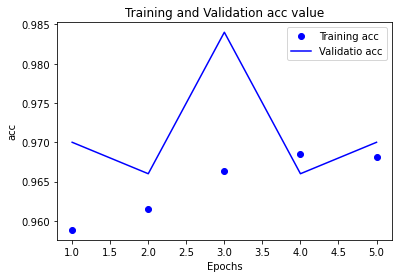

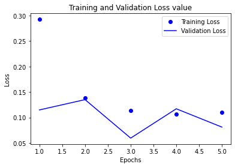

```python
#history_dict = history.history
acc = history.history['accuracy']
val_acc = history.history['val_accuracy']
loss = history.history['loss']
val_loss = history.history['val_loss']

epochs = range(1, len(acc) + 1)
plt.plot(epochs, acc, 'bo', label='Training acc')
plt.plot(epochs, val_acc, 'b', label='Validatio acc')
plt.title('Training and Validation acc value')
plt.xlabel('Epochs')
plt.ylabel('acc')
plt.legend()

plt.figure()

plt.plot(epochs, loss, 'bo', label='Training Loss')
plt.plot(epochs, val_loss, 'b', label='Validation Loss')
plt.title('Training and Validation Loss value')
plt.xlabel('Epochs')
plt.ylabel('Loss')
plt.legend()

plt.show()
```

### e) Test set Predtiction

```python
y_pred = np.argmax(VGGFace_model.predict(test_set), axis=-1)
y_pred
```

```
array([0, 0, 0, ..., 1, 1, 1], dtype=int64)
```

```python
y_true = test_set.classes
y_true
```

```
array([0, 0, 0, ..., 1, 1, 1])
```

```python
cm = confusion_matrix(y_true, y_pred)
cm
```

```
array([[1955,   45],
       [  61, 1939]], dtype=int64)
```

```python
target_names = ['female', 'male']
cr = classification_report(y_true, y_pred, target_names=target_names)
print(cr)
```

```
              precision    recall  f1-score   support

      female       0.97      0.98      0.97      2000
        male       0.98      0.97      0.97      2000

    accuracy                           0.97      4000
   macro avg       0.97      0.97      0.97      4000
weighted avg       0.97      0.97      0.97      4000
```

```
confusion matrix, without normalization
[[1955   45]
 [  61 1939]]
```

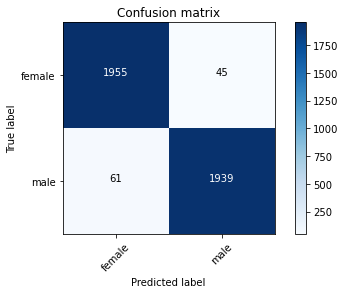

```python
plot_confusion_matrix(cm=cm, classes=target_names, title="Confusion matrix")
```

### f) Transgender set Prediction

```python
y_pred_trans = np.argmax(VGGFace_model.predict(Test_trans_set), axis=-1)
y_pred_trans
```

```
array([1, 1, 1, ..., 0, 0, 0], dtype=int64)
```

```python
y_true_trans = Test_trans_set.classes
y_true_trans
```

```
array([0, 0, 0, ..., 1, 1, 1])
```

```python
cm_trans = confusion_matrix(y_true_trans, y_pred_trans)
cm_trans
```

```
array([[ 44, 616],
       [504, 156]], dtype=int64)
```

```python
target_names = ['female', 'male']
cr_trans = classification_report(y_true_trans, y_pred_trans, target_names=target_names)
print(cr_trans)
```

```
              precision    recall  f1-score   support

      female       0.08      0.07      0.07       660
        male       0.20      0.24      0.22       660

    accuracy                           0.15      1320
   macro avg       0.14      0.15      0.15      1320
weighted avg       0.14      0.15      0.15      1320
```

```
confusion matrix, without normalization
[[ 44 616]
 [504 156]]
```

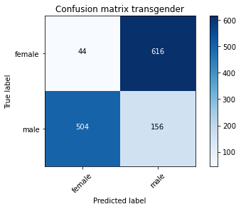

```python
plot_confusion_matrix(cm=cm_trans, classes=target_names, title="Confusion matrix transgender")
```

# 4. ResNet50

```python
from tensorflow.keras.applications.resnet50 import ResNet50
from tensorflow.keras.preprocessing import image
from tensorflow.keras.applications.resnet50 import preprocess_input, decode_predictions
```

### a) Build the Model

```python
base_model = ResNet50(weights='imagenet', include_top=False)
```

```python
base_model.summary()
```

```
Model: "resnet50"
__________________________________________________________________________________________________
Layer (type)                    Output Shape         Param #     Connected to
==================================================================================================
input_5 (InputLayer)            [(None, None, None,  0
__________________________________________________________________________________________________
conv1_pad (ZeroPadding2D)       (None, None, None, 3 0           input_5[0][0]
__________________________________________________________________________________________________
conv1_conv (Conv2D)             (None, None, None, 6 9472        conv1_pad[0][0]
__________________________________________________________________________________________________
conv1_bn (BatchNormalization)   (None, None, None, 6 256         conv1_conv[0][0]
__________________________________________________________________________________________________
conv1_relu (Activation)         (None, None, None, 6 0           conv1_bn[0][0]
__________________________________________________________________________________________________
pool1_pad (ZeroPadding2D)       (None, None, None, 6 0           conv1_relu[0][0]
__________________________________________________________________________________________________
pool1_pool (MaxPooling2D)       (None, None, None, 6 0           pool1_pad[0][0]
__________________________________________________________________________________________________
conv2_block1_1_conv (Conv2D)    (None, None, None, 6 4160        pool1_pool[0][0]
__________________________________________________________________________________________________
conv2_block1_1_bn (BatchNormali (None, None, None, 6 256         conv2_block1_1_conv[0][0]
__________________________________________________________________________________________________
conv2_block1_1_relu (Activation (None, None, None, 6 0           conv2_block1_1_bn[0][0]
__________________________________________________________________________________________________
conv2_block1_2_conv (Conv2D)    (None, None, None, 6 36928       conv2_block1_1_relu[0][0]
__________________________________________________________________________________________________
conv2_block1_2_bn (BatchNormali (None, None, None, 6 256         conv2_block1_2_conv[0][0]
__________________________________________________________________________________________________
conv2_block1_2_relu (Activation (None, None, None, 6 0           conv2_block1_2_bn[0][0]
__________________________________________________________________________________________________
conv2_block1_0_conv (Conv2D)    (None, None, None, 2 16640       pool1_pool[0][0]
__________________________________________________________________________________________________
conv2_block1_3_conv (Conv2D)    (None, None, None, 2 16640       conv2_block1_2_relu[0][0]
__________________________________________________________________________________________________
conv2_block1_0_bn (BatchNormali (None, None, None, 2 1024        conv2_block1_0_conv[0][0]
__________________________________________________________________________________________________
conv2_block1_3_bn (BatchNormali (None, None, None, 2 1024        conv2_block1_3_conv[0][0]
__________________________________________________________________________________________________
conv2_block1_add (Add)          (None, None, None, 2 0           conv2_block1_0_bn[0][0]
                                                                 conv2_block1_3_bn[0][0]
```

[output cut: 319 more lines]

```
conv5_block3_2_relu (Activation (None, None, None, 5 0           conv5_block3_2_bn[0][0]
__________________________________________________________________________________________________
conv5_block3_3_conv (Conv2D)    (None, None, None, 2 1050624     conv5_block3_2_relu[0][0]
__________________________________________________________________________________________________
conv5_block3_3_bn (BatchNormali (None, None, None, 2 8192        conv5_block3_3_conv[0][0]
__________________________________________________________________________________________________
conv5_block3_add (Add)          (None, None, None, 2 0           conv5_block2_out[0][0]
                                                                 conv5_block3_3_bn[0][0]
__________________________________________________________________________________________________
conv5_block3_out (Activation)   (None, None, None, 2 0           conv5_block3_add[0][0]
==================================================================================================
Total params: 23,587,712
Trainable params: 23,534,592
Non-trainable params: 53,120
__________________________________________________________________________________________________
```

```python
# add a global spatial average pooling layer
x = base_model.output
x = GlobalAveragePooling2D()(x)
# let's add a fully-connected layer
x = Dense(1024, activation='relu')(x)
# and a logistic layer -- let's say we have 200 classes
predictions = Dense(2, activation='softmax')(x)

# this is the model we will train
ResNet50_model = Model(inputs=base_model.input, outputs=predictions)
```

```python
# first: train only the top layers (which were randomly initialized)
# i.e. freeze all convolutional InceptionV3 layers
for layer in base_model.layers:
    layer.trainable = False
```

```python
# let's visualize layer names and layer indices to see how many layers
# we should freeze:
for i, layer in enumerate(base_model.layers):
   print(i, layer.name)
```

```
0 input_5
1 conv1_pad
2 conv1_conv
3 conv1_bn
4 conv1_relu
5 pool1_pad
6 pool1_pool
7 conv2_block1_1_conv
8 conv2_block1_1_bn
9 conv2_block1_1_relu
10 conv2_block1_2_conv
11 conv2_block1_2_bn
12 conv2_block1_2_relu
13 conv2_block1_0_conv
14 conv2_block1_3_conv
```

[output cut: 160 more lines]

```python
ResNet50_model.compile(optimizer = 'adam', loss = 'categorical_crossentropy', metrics = ['accuracy'])
```

### b) Preprocessing

```python
train_datagen = ImageDataGenerator(preprocessing_function=preprocess_input)

test_datagen = ImageDataGenerator(preprocessing_function=preprocess_input)
```

```python
training_set = train_datagen.flow_from_directory('dataset/Training',
                                                 target_size = (224, 224),
                                                 batch_size = 10,
                                                 class_mode = 'categorical')

val_set = test_datagen.flow_from_directory('dataset/Validation',
                                            target_size = (224, 224),
                                                 batch_size = 10,
                                                class_mode = 'categorical')
                                            #class_mode = 'binary'

test_set = test_datagen.flow_from_directory('dataset/Test',
                                            target_size = (224, 224),
                                            batch_size = 10,
                                            class_mode = 'categorical', shuffle=False)
                                            #class_mode = 'binary'

Test_trans_set = test_datagen.flow_from_directory('dataset/Test_trans',
                                            target_size = (224, 224),
                                            batch_size = 10,
                                            class_mode = 'categorical', shuffle=False)
                                            #class_mode = 'binary'
```

```
Found 43009 images belonging to 2 classes.
Found 11649 images belonging to 2 classes.
Found 4000 images belonging to 2 classes.
Found 1320 images belonging to 2 classes.
```

### c) Train the Model

```python
history=ResNet50_model.fit(training_set,
                         steps_per_epoch = 1344, # if batch_size=1 -> steps_per_epoch=8000
                         epochs = 5,
                         validation_data = val_set,
                         validation_steps = 50)
```

```python
# # save the model
# ResNet50_model.save('ResNet50_model.h5')
```

```python
# # Loading the model
# ResNet50_model = load_model('ResNet50_model.h5')
# ResNet50_model.summary()
```

### d) Displaying curves of loss and accuracy during training

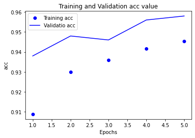

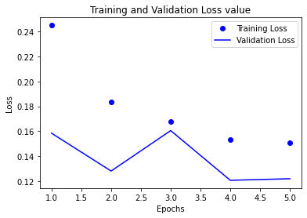

```python
#history_dict = history.history
acc = history.history['accuracy']
val_acc = history.history['val_accuracy']
loss = history.history['loss']
val_loss = history.history['val_loss']

epochs = range(1, len(acc) + 1)
plt.plot(epochs, acc, 'bo', label='Training acc')
plt.plot(epochs, val_acc, 'b', label='Validatio acc')
plt.title('Training and Validation acc value')
plt.xlabel('Epochs')
plt.ylabel('acc')
plt.legend()

plt.figure()

plt.plot(epochs, loss, 'bo', label='Training Loss')
plt.plot(epochs, val_loss, 'b', label='Validation Loss')
plt.title('Training and Validation Loss value')
plt.xlabel('Epochs')
plt.ylabel('Loss')
plt.legend()

plt.show()
```

### e) Test set Prediction

```python
y_pred = np.argmax(ResNet50_model.predict(test_set), axis=-1)
y_pred
```

```
array([0, 0, 1, ..., 1, 1, 1], dtype=int64)
```

```python
y_true = test_set.classes
y_true
```

```
array([0, 0, 0, ..., 1, 1, 1])
```

```python
cm = confusion_matrix(y_true, y_pred)
cm
```

```
array([[1921,   79],
       [ 108, 1892]], dtype=int64)
```

```python
target_names = ['female', 'male']
cr = classification_report(y_true, y_pred, target_names=target_names)
print(cr)
```

```
              precision    recall  f1-score   support

      female       0.95      0.96      0.95      2000
        male       0.96      0.95      0.95      2000

    accuracy                           0.95      4000
   macro avg       0.95      0.95      0.95      4000
weighted avg       0.95      0.95      0.95      4000
```

```
confusion matrix, without normalization
[[1921   79]
 [ 108 1892]]
```

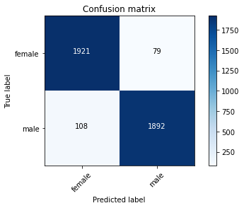

```python
plot_confusion_matrix(cm=cm, classes=target_names, title="Confusion matrix")
```

### f) Trandender set Prediction

```python
y_pred_trans = np.argmax(ResNet50_model.predict(Test_trans_set), axis=-1)
y_pred_trans
```

```
array([1, 1, 1, ..., 0, 0, 0], dtype=int64)
```

```python
y_true_trans = Test_trans_set.classes
y_true_trans
```

```
array([0, 0, 0, ..., 1, 1, 1])
```

```python
cm_trans = confusion_matrix(y_true_trans, y_pred_trans)
cm_trans
```

```
array([[ 93, 567],
       [578,  82]], dtype=int64)
```

```python
target_names = ['female', 'male']
cr_trans = classification_report(y_true_trans, y_pred_trans, target_names=target_names)
print(cr_trans)
```

```
              precision    recall  f1-score   support

      female       0.14      0.14      0.14       660
        male       0.13      0.12      0.13       660

    accuracy                           0.13      1320
   macro avg       0.13      0.13      0.13      1320
weighted avg       0.13      0.13      0.13      1320
```

```
confusion matrix, without normalization
[[1921   79]
 [ 108 1892]]
```

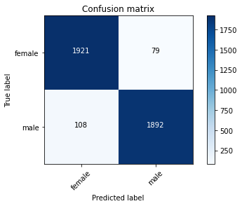

```python
plot_confusion_matrix(cm=cm, classes=target_names, title="Confusion matrix")
```

```
confusion matrix, without normalization
[[ 93 567]
 [578  82]]
```

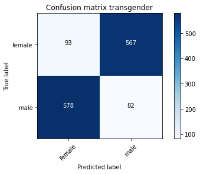

```python
plot_confusion_matrix(cm=cm_trans, classes=target_names, title="Confusion matrix transgender")
```

# 5. Xception

Xception — With Depthwise Separable Convolution, Better Than Inception-v3 (Image Classification)

Xception [1] by Google, stands for Extreme version of Inception, is reviewed. With a modified depthwise separable convolution, it is even better than Inception-v3 [2] (also by Google, 1st Runner Up in ILSVRC 2015) for both ImageNet ILSVRC and JFT datasets.

[2017 CVPR] [Xception] Xception: Deep Learning with Depthwise Separable Convolutions  
[2016 CVPR] [Inception-v3] Rethinking the Inception Architecture for Computer Vision

```python
from keras.applications.xception import Xception
from tensorflow.keras.applications.xception import preprocess_input
from keras.models import Model
from keras.layers import Dense, GlobalAveragePooling2D
from keras import backend as K
```

```python
# create the base pre-trained model
base_model = Xception(weights='imagenet', include_top=False)
```

```python
base_model.summary()
```

```
Model: "xception"
__________________________________________________________________________________________________
Layer (type)                    Output Shape         Param #     Connected to
==================================================================================================
input_6 (InputLayer)            [(None, None, None,  0
__________________________________________________________________________________________________
block1_conv1 (Conv2D)           (None, None, None, 3 864         input_6[0][0]
__________________________________________________________________________________________________
block1_conv1_bn (BatchNormaliza (None, None, None, 3 128         block1_conv1[0][0]
__________________________________________________________________________________________________
block1_conv1_act (Activation)   (None, None, None, 3 0           block1_conv1_bn[0][0]
__________________________________________________________________________________________________
block1_conv2 (Conv2D)           (None, None, None, 6 18432       block1_conv1_act[0][0]
__________________________________________________________________________________________________
block1_conv2_bn (BatchNormaliza (None, None, None, 6 256         block1_conv2[0][0]
__________________________________________________________________________________________________
block1_conv2_act (Activation)   (None, None, None, 6 0           block1_conv2_bn[0][0]
__________________________________________________________________________________________________
block2_sepconv1 (SeparableConv2 (None, None, None, 1 8768        block1_conv2_act[0][0]
__________________________________________________________________________________________________
block2_sepconv1_bn (BatchNormal (None, None, None, 1 512         block2_sepconv1[0][0]
__________________________________________________________________________________________________
block2_sepconv2_act (Activation (None, None, None, 1 0           block2_sepconv1_bn[0][0]
__________________________________________________________________________________________________
block2_sepconv2 (SeparableConv2 (None, None, None, 1 17536       block2_sepconv2_act[0][0]
__________________________________________________________________________________________________
block2_sepconv2_bn (BatchNormal (None, None, None, 1 512         block2_sepconv2[0][0]
__________________________________________________________________________________________________
conv2d (Conv2D)                 (None, None, None, 1 8192        block1_conv2_act[0][0]
__________________________________________________________________________________________________
block2_pool (MaxPooling2D)      (None, None, None, 1 0           block2_sepconv2_bn[0][0]
__________________________________________________________________________________________________
batch_normalization (BatchNorma (None, None, None, 1 512         conv2d[0][0]
__________________________________________________________________________________________________
add_32 (Add)                    (None, None, None, 1 0           block2_pool[0][0]
                                                                 batch_normalization[0][0]
__________________________________________________________________________________________________
block3_sepconv1_act (Activation (None, None, None, 1 0           add_32[0][0]
__________________________________________________________________________________________________
block3_sepconv1 (SeparableConv2 (None, None, None, 2 33920       block3_sepconv1_act[0][0]
```

[output cut: 229 more lines]

```
__________________________________________________________________________________________________
block14_sepconv1_bn (BatchNorma (None, None, None, 1 6144        block14_sepconv1[0][0]
__________________________________________________________________________________________________
block14_sepconv1_act (Activatio (None, None, None, 1 0           block14_sepconv1_bn[0][0]
__________________________________________________________________________________________________
block14_sepconv2 (SeparableConv (None, None, None, 2 3159552     block14_sepconv1_act[0][0]
__________________________________________________________________________________________________
block14_sepconv2_bn (BatchNorma (None, None, None, 2 8192        block14_sepconv2[0][0]
__________________________________________________________________________________________________
block14_sepconv2_act (Activatio (None, None, None, 2 0           block14_sepconv2_bn[0][0]
==================================================================================================
Total params: 20,861,480
Trainable params: 20,806,952
Non-trainable params: 54,528
__________________________________________________________________________________________________
```

```python
# add a global spatial average pooling layer
x = base_model.output
x = GlobalAveragePooling2D()(x)
# let's add a fully-connected layer
x = Dense(1024, activation='relu')(x)
# and a logistic layer -- let's say we have 200 classes
predictions = Dense(2, activation='softmax')(x)

# this is the model we will train
Xception_model = Model(inputs=base_model.input, outputs=predictions)
```

```python
# first: train only the top layers (which were randomly initialized)
# i.e. freeze all convolutional InceptionV3 layers
for layer in base_model.layers:
    layer.trainable = False
```

```python
Xception_model.summary()
```

```
Model: "model_2"
__________________________________________________________________________________________________
Layer (type)                    Output Shape         Param #     Connected to
==================================================================================================
input_6 (InputLayer)            [(None, None, None,  0
__________________________________________________________________________________________________
block1_conv1 (Conv2D)           (None, None, None, 3 864         input_6[0][0]
__________________________________________________________________________________________________
block1_conv1_bn (BatchNormaliza (None, None, None, 3 128         block1_conv1[0][0]
__________________________________________________________________________________________________
block1_conv1_act (Activation)   (None, None, None, 3 0           block1_conv1_bn[0][0]
__________________________________________________________________________________________________
block1_conv2 (Conv2D)           (None, None, None, 6 18432       block1_conv1_act[0][0]
__________________________________________________________________________________________________
block1_conv2_bn (BatchNormaliza (None, None, None, 6 256         block1_conv2[0][0]
__________________________________________________________________________________________________
block1_conv2_act (Activation)   (None, None, None, 6 0           block1_conv2_bn[0][0]
__________________________________________________________________________________________________
block2_sepconv1 (SeparableConv2 (None, None, None, 1 8768        block1_conv2_act[0][0]
__________________________________________________________________________________________________
block2_sepconv1_bn (BatchNormal (None, None, None, 1 512         block2_sepconv1[0][0]
__________________________________________________________________________________________________
block2_sepconv2_act (Activation (None, None, None, 1 0           block2_sepconv1_bn[0][0]
__________________________________________________________________________________________________
block2_sepconv2 (SeparableConv2 (None, None, None, 1 17536       block2_sepconv2_act[0][0]
__________________________________________________________________________________________________
block2_sepconv2_bn (BatchNormal (None, None, None, 1 512         block2_sepconv2[0][0]
__________________________________________________________________________________________________
conv2d (Conv2D)                 (None, None, None, 1 8192        block1_conv2_act[0][0]
__________________________________________________________________________________________________
block2_pool (MaxPooling2D)      (None, None, None, 1 0           block2_sepconv2_bn[0][0]
__________________________________________________________________________________________________
batch_normalization (BatchNorma (None, None, None, 1 512         conv2d[0][0]
__________________________________________________________________________________________________
add_32 (Add)                    (None, None, None, 1 0           block2_pool[0][0]
                                                                 batch_normalization[0][0]
__________________________________________________________________________________________________
block3_sepconv1_act (Activation (None, None, None, 1 0           add_32[0][0]
__________________________________________________________________________________________________
block3_sepconv1 (SeparableConv2 (None, None, None, 2 33920       block3_sepconv1_act[0][0]
```

[output cut: 235 more lines]

```
__________________________________________________________________________________________________
block14_sepconv2_bn (BatchNorma (None, None, None, 2 8192        block14_sepconv2[0][0]
__________________________________________________________________________________________________
block14_sepconv2_act (Activatio (None, None, None, 2 0           block14_sepconv2_bn[0][0]
__________________________________________________________________________________________________
global_average_pooling2d_34 (Gl (None, 2048)         0           block14_sepconv2_act[0][0]
__________________________________________________________________________________________________
dense_7 (Dense)                 (None, 1024)         2098176     global_average_pooling2d_34[0][0]
__________________________________________________________________________________________________
dense_8 (Dense)                 (None, 2)            2050        dense_7[0][0]
==================================================================================================
Total params: 22,961,706
Trainable params: 2,100,226
Non-trainable params: 20,861,480
__________________________________________________________________________________________________
```

```python
# let's visualize layer names and layer indices to see how many layers
# we should freeze:
for i, layer in enumerate(base_model.layers):
    print(i, layer.name)
```

```
0 input_6
1 block1_conv1
2 block1_conv1_bn
3 block1_conv1_act
4 block1_conv2
5 block1_conv2_bn
6 block1_conv2_act
7 block2_sepconv1
8 block2_sepconv1_bn
9 block2_sepconv2_act
10 block2_sepconv2
11 block2_sepconv2_bn
12 conv2d
13 block2_pool
14 batch_normalization
```

[output cut: 117 more lines]

```python
# compile the model (should be done *after* setting layers to non-trainable)
#Xception_model.compile(optimizer='rmsprop', loss='categorical_crossentropy')

Xception_model.compile(optimizer = 'adam', loss = 'categorical_crossentropy', metrics = ['accuracy'])
```

### b) Preprocessing

```python
train_datagen = ImageDataGenerator(preprocessing_function=preprocess_input)

test_datagen = ImageDataGenerator(preprocessing_function=preprocess_input)
```

```python
training_set = train_datagen.flow_from_directory('dataset/Training',
                                                 target_size = (224, 224),
                                                 batch_size = 10,
                                                 class_mode = 'categorical')

val_set = test_datagen.flow_from_directory('dataset/Validation',
                                            target_size = (224, 224),
                                                 batch_size = 10,
                                                class_mode = 'categorical')
                                            #class_mode = 'binary'

test_set = test_datagen.flow_from_directory('dataset/Test',
                                            target_size = (224, 224),
                                            batch_size = 10,
                                            class_mode = 'categorical', shuffle=False)
                                            #class_mode = 'binary'

Test_trans_set = test_datagen.flow_from_directory('dataset/Test_trans',
                                            target_size = (224, 224),
                                            batch_size = 10,
                                            class_mode = 'categorical', shuffle=False)
                                            #class_mode = 'binary
```

```
Found 43009 images belonging to 2 classes.
Found 11649 images belonging to 2 classes.
Found 4000 images belonging to 2 classes.
Found 1320 images belonging to 2 classes.
```

### c) Train the model

```python
history=Xception_model.fit(training_set,
                         steps_per_epoch = 1344, # if batch_size=1 -> steps_per_epoch=8000
                         epochs = 5,
                         validation_data = val_set,
                         validation_steps = 50)
```

```python
# # save the model
# Xception_model.save('Xception_model2.h5')
```

```python
# # Loading the model
# Xception_model = load_model('Xception_model2.h5')
# Xception_model.summary()
```

[output not shown]

[output cut: 235 more lines]

[output not shown]

### d) Displaying curves of loss and accuracy during training

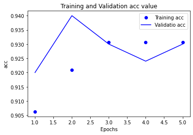

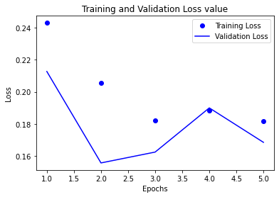

```python
#history_dict = history.history
acc = history.history['accuracy']
val_acc = history.history['val_accuracy']
loss = history.history['loss']
val_loss = history.history['val_loss']

epochs = range(1, len(acc) + 1)
plt.plot(epochs, acc, 'bo', label='Training acc')
plt.plot(epochs, val_acc, 'b', label='Validatio acc')
plt.title('Training and Validation acc value')
plt.xlabel('Epochs')
plt.ylabel('acc')
plt.legend()

plt.figure()

plt.plot(epochs, loss, 'bo', label='Training Loss')
plt.plot(epochs, val_loss, 'b', label='Validation Loss')
plt.title('Training and Validation Loss value')
plt.xlabel('Epochs')
plt.ylabel('Loss')
plt.legend()

plt.show()
```

### e) Test set Prediction

```python
y_pred = np.argmax(Xception_model.predict(test_set), axis=-1)
y_pred
```

```
array([0, 0, 1, ..., 1, 1, 1], dtype=int64)
```

```python
y_true = test_set.classes
y_true
```

```
array([0, 0, 0, ..., 1, 1, 1])
```

```python
cm = confusion_matrix(y_true, y_pred)
cm
```

```
array([[1905,   95],
       [ 150, 1850]], dtype=int64)
```

```python
target_names = ['female', 'male']
cr = classification_report(y_true, y_pred, target_names=target_names)
print(cr)
```

```
              precision    recall  f1-score   support

      female       0.93      0.95      0.94      2000
        male       0.95      0.93      0.94      2000

    accuracy                           0.94      4000
   macro avg       0.94      0.94      0.94      4000
weighted avg       0.94      0.94      0.94      4000
```

```
confusion matrix, without normalization
[[1905   95]
 [ 150 1850]]
```

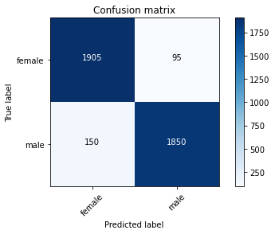

```python
plot_confusion_matrix(cm=cm, classes=target_names, title="Confusion matrix")
```

### f) Trangender Prediction

```python
y_pred_trans = np.argmax(Xception_model.predict(Test_trans_set), axis=-1)
y_pred_trans
```

```
array([0, 0, 1, ..., 0, 0, 0], dtype=int64)
```

```python
y_true_trans = Test_trans_set.classes
y_true_trans
```

```
array([0, 0, 0, ..., 1, 1, 1])
```

```python
cm_trans = confusion_matrix(y_true_trans, y_pred_trans)
cm_trans
```

```
array([[160, 500],
       [613,  47]], dtype=int64)
```

```python
cm_trans = confusion_matrix(y_true_trans, y_pred_trans)
cm_trans
```

```
array([[160, 500],
       [613,  47]], dtype=int64)
```

```python
target_names = ['female', 'male']
cr_trans = classification_report(y_true_trans, y_pred_trans, target_names=target_names)
print(cr_trans)
```

```
              precision    recall  f1-score   support

      female       0.21      0.24      0.22       660
        male       0.09      0.07      0.08       660

    accuracy                           0.16      1320
   macro avg       0.15      0.16      0.15      1320
weighted avg       0.15      0.16      0.15      1320
```

```
confusion matrix, without normalization
[[160 500]
 [613  47]]
```

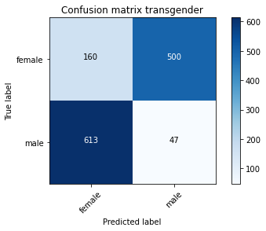

```python
plot_confusion_matrix(cm=cm_trans, classes=target_names, title="Confusion matrix transgender")
```

# 10. Extensions

Back to TOC

Create a Function. Update the example and add a function that given an image filename and the loaded model will return the classification result.